# REPORT: A Research of the Effects of Disaster Evnets on Public Health and Wealth in US by Means of Analysis of NOAA Disaster Event Data Base

## 2 Results

This section aims to provide analysis for the two following problems:

- Across the United States, which types of events are most harmful with respect to population health?
- Across the United States, which types of events have the greatest economic consequences?

### 2.1 Results: Public Health

Preparation

```r
# empty DFs to be used later in preparation of individual subsets
PHDangers <- data.frame()
PWDangersP <- data.frame()
PWDangersC <- data.frame()
```

Subsetting of PH events

```r
for (i in 1:length(EvName)){
    if (i != 6) {
        tdf <- aggregate(cbind(fatalities, injuries) ~ mydataC[,i+10], sum, data = mydataC)
        names(tdf) <- c("evtype", "fatalities", "injuries")
        tdf$evcount <- length(subset(mydataC[,i+10],
                                     mydataC [,i+10] != "NA"))
        PHDangers <- rbind(PHDangers, tdf)

    }
}
fatTop2 <- PHDangers
```

Subsetting top ten most dangerous event types in terms of fatalities

```r
# Sum
fatTopF <- fatTop2[order(fatTop2[,2], decreasing=F),]
fatTopF <- tail(fatTopF, 10)
fatTopF
```

```
##                        evtype fatalities injuries evcount
## 12 Extreme_Cold_OR_Wind_Chill        402      272    2560
## 23                  High_Wind        428     1885   26015
## 37          Thunderstorm_Wind        465     6188  245780
## 14                      Flood        483     6794   26117
## 33                Rip_Current        577      529     776
## 28                  Lightning        816     5230   15761
## 13                Flash_Flood       1035     1800   55662
## 19                       Heat       1114     2479     844
## 38                    Tornado       1624    23370   25930
## 11             Excessive_Heat       2020     6730    1798
```

```r
# Mean
fatTopFM <- transform(fatTop2, new = round(fatalities / evcount, digits = 0))
fatTopFM <- fatTopFM[order(fatTopFM[,5], decreasing=F),]
fatTopFM <- tail(fatTopFM, 10)
```

Subsetting top ten most dangerous event types in terms of injuries

```r
# Sum
fatTopI <- fatTop2[order(fatTop2[,3], decreasing=F),]
fatTopI <- tail(fatTopI, 10)
fatTopI
```

```
##               evtype fatalities injuries evcount
## 44          Wildfire         90     1608    4233
## 13       Flash_Flood       1035     1800   55662
## 23         High_Wind        428     1885   26015
## 25         Ice_Storm         90     1986    2036
## 19              Heat       1114     2479     844
## 28         Lightning        816     5230   15761
## 37 Thunderstorm_Wind        465     6188  245780
## 11    Excessive_Heat       2020     6730    1798
## 14             Flood        483     6794   26117
## 38           Tornado       1624    23370   25930
```

```r
# Mean
fatTopIM <- transform(fatTop2, new = round(injuries / evcount, digits = 0))
fatTopIM <- fatTopIM[order(fatTopIM[,5], decreasing=F),]
fatTopIM <- tail(fatTopIM, 10)
```

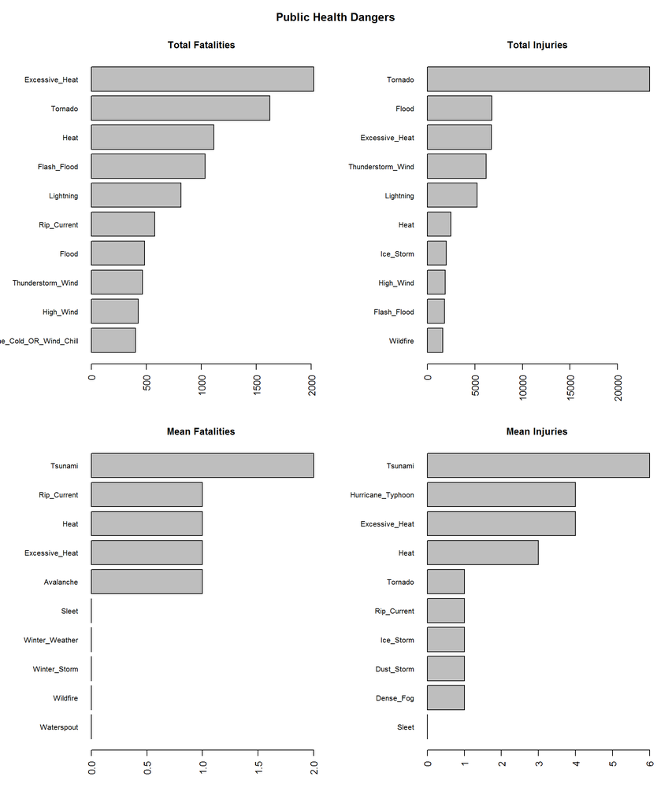

```r
par(mfrow=c(2,2))
par(las=2)
par(mar=c(5,8,2,2))
par(oma=c(0,0,3,0))

# sum plots
barplot(fatTopF$fatalities, main="Total Fatalities", horiz=TRUE,
        names.arg=fatTopF$evtype, cex.names=0.8, cex.main = 1)
barplot(fatTopI$injuries, main="Total Injuries", horiz=TRUE,
        names.arg=fatTopI$evtype, cex.names=0.8, cex.main = 1)

# mean plots
barplot(fatTopFM$new, main="Mean Fatalities", horiz=TRUE,
        names.arg=fatTopFM$evtype, cex.names=0.8, cex.main = 1)
barplot(fatTopIM$new, main="Mean Injuries", horiz=TRUE,
        names.arg=fatTopIM$evtype, cex.names=0.8, cex.main = 1)

# main caption
title("Public Health Dangers", outer=T)
```

### 2.2 Results: Public Wealth

Subsetting the public wealth dangers

```r
mydataL <- mydataC
mydataL [, 7] <- as.factor(tolower(mydataL [, 7]))
mydataL [, 9] <- as.factor(tolower(mydataL [, 9]))
mydataPW2Prop <- subset(mydataL,
                        propdmgexp %in% c("k","m","b"))
mydataPW2Crop <- subset(mydataL,
                        cropdmgexp %in% c("k","m","b"))

# multiplication of property damage
for (i in 1:length(mydataPW2Prop)) {
    if (mydataPW2Prop[i, 6] == "k") {
        mydataPW2Prop[i, 6] <- mydataPW2Prop[i, 6]*1000
    } else if (mydataPW2Prop[i, 6] == "m") {
        mydataPW2Prop[i, 6] <- mydataPW2Prop[i, 6]*1000000
    } else {
        mydataPW2Prop[i, 6] <- mydataPW2Prop[i, 6]*1000000000
    }
}

# multiplication of crop damage
for (i in 1:length(mydataPW2Crop)) {
    if (mydataPW2Crop[i, 8] == "k") {
        mydataPW2Crop[i, 8] <- mydataPW2Crop[i, 8]*1000
    } else if (mydataPW2Crop[i, 8] == "m") {
        mydataPW2Crop[i, 8] <- mydataPW2Crop[i, 8]*1000000
    } else {
        mydataPW2Crop[i, 8] <- mydataPW2Crop[i, 8]*1000000000
    }
}
```

The crop damage table

```r
# i <- 1
for (i in 1:length(EvName)){
    if (i != 6) {
        tdf2 <- aggregate(cropdmg ~ mydataPW2Crop[,i+10], sum,
                          data = mydataPW2Crop)
        names(tdf2) <- c("evtype", "cropdmg")
        tdf2$evcount <- length(subset(mydataPW2Crop[,i+10],
                                      mydataPW2Crop[,i+10] != "NA"))
        PWDangersC <- rbind(PWDangersC, tdf2)
    }
}
cropTop2 <- PWDangersC
```

```r
for (i in 1:length(EvName)){
    if (i != 6) {
        tdf3 <- aggregate(cropdmg ~ mydataPW2Prop[,i+10], sum,
                          data = mydataPW2Prop)
        names(tdf3) <- c("evtype", "propdmg")
        tdf3$evcount <- length(subset(mydataPW2Prop[,i+10],
                                      mydataPW2Prop[,i+10] != "NA"))
        PWDangersP <- rbind(PWDangersP, tdf3)
    }
}
propTop2 <- PWDangersP
```

```r
# sum
propTopN <- propTop2[order(propTop2[,2], decreasing=F),]
propTopN <- tail(propTopN, 10)
propTopN
```

```
##               evtype   propdmg evcount
## 15   Frost_OR_Freeze   7302.00    1109
## 20        Heavy_Rain   7866.49    5844
## 24 Hurricane_Typhoon  11444.79     221
## 8            Drought  18351.98    1407
## 23         High_Wind  22199.71   18231
## 38           Tornado  93693.77   17084
## 14             Flood 171005.32   17827
## 37 Thunderstorm_Wind 178477.03  162984
## 13       Flash_Flood 182980.69   33550
## 18              Hail 421626.75   92637
```

```r
# mean
propTopNM <- transform(propTop2, new = round(propdmg / evcount, digits = 0))
propTopNM <- propTopNM[order(propTopNM[,4], decreasing=F),]
propTopNM <- tail(propTopNM, 10)
propTopNM
```

```
##                evtype   propdmg evcount new
## 10         Dust_Storm    851.50     238   4
## 5  Cold_OR_Wind_Chill   2605.00     534   5
## 13        Flash_Flood 182980.69   33550   5
## 18               Hail 421626.75   92637   5
## 38            Tornado  93693.77   17084   5
## 15    Frost_OR_Freeze   7302.00    1109   7
## 40     Tropical_Storm   4704.52     623   8
## 14              Flood 171005.32   17827  10
## 8             Drought  18351.98    1407  13
## 24  Hurricane_Typhoon  11444.79     221  52
```

Subsetting top ten most dangerous event types in terms of crop damage

```r
# sum
cropTopN <- cropTop2[order(cropTop2[,2], decreasing=F),]
cropTopN <- tail(cropTopN, 10)
cropTopN
```

```
##               evtype      cropdmg evcount
## 19              Heat 4.000009e+08     636
## 20        Heavy_Rain 5.000013e+09    5324
## 24 Hurricane_Typhoon 1.500001e+10     116
## 23         High_Wind 1.040000e+11   14107
## 38           Tornado 2.615501e+11    9597
## 18              Hail 2.910006e+11   82651
## 45      Winter_Storm 5.050000e+11    6716
## 13       Flash_Flood 7.600002e+11   21776
## 14             Flood 1.015000e+12   13787
## 37 Thunderstorm_Wind 1.183500e+12   94905
```

```r
# mean
cropTopNM <- transform(cropTop2, new = round(cropdmg / evcount, digits = 0))
cropTopNM <- cropTopNM[order(cropTopNM[,4], decreasing=F),]
cropTopNM <- tail(cropTopNM, 10)
cropTopNM
```

```
##               evtype      cropdmg evcount       new
## 19              Heat 4.000009e+08     636    628932
## 20        Heavy_Rain 5.000013e+09    5324    939146
## 18              Hail 2.910006e+11   82651   3520836
## 23         High_Wind 1.040000e+11   14107   7372228
## 37 Thunderstorm_Wind 1.183500e+12   94905  12470367
## 38           Tornado 2.615501e+11    9597  27253319
## 13       Flash_Flood 7.600002e+11   21776  34900817
## 14             Flood 1.015000e+12   13787  73620090
## 45      Winter_Storm 5.050000e+11    6716  75193568
## 24 Hurricane_Typhoon 1.500001e+10     116 129310445
```

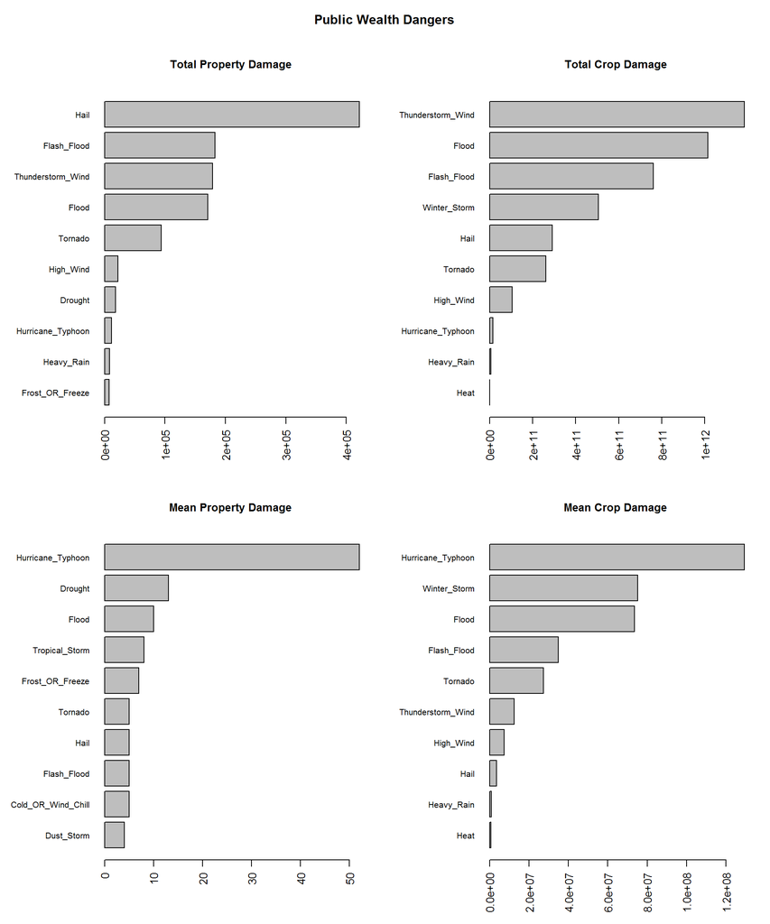

```r
par(mfrow=c(2,2))
par(las=2)
par(mar=c(5,8,4,2))
par(oma=c(0,0,3,0))

#sum
barplot(propTopN$propdmg, main="Total Property Damage", horiz=TRUE,
        names.arg=propTopN$evtype, cex.names=0.8, cex.main = 1)
barplot(cropTopN$cropdmg, main="Total Crop Damage", horiz=TRUE,
        names.arg=cropTopN$evtype, cex.names=0.8, cex.main = 1)

#mean
barplot(propTopNM$new, main="Mean Property Damage", horiz=TRUE,
        names.arg=propTopNM$evtype, cex.names=0.8, cex.main = 1)
barplot(cropTopNM$new, main="Mean Crop Damage", horiz=TRUE,
        names.arg=cropTopNM$evtype, cex.names=0.8, cex.main = 1)

# main caption
title("Public Wealth Dangers", outer=T)
```